# Trabajo 1 de Análisis y Visualización de Datos

Luís Filipe Milhomem da Silva Paixão y Marcos Folguera Rivera

09 de marzo de 2023

# Base de datos

*cpus* usado en el análisis está contenido en el paquete **MASS**. Contiene medidas sobre el rendimiento real y estimado de 209 CPUs, así como otras características técnicas.

```r
set.seed(157)
library(MASS)
data(cpus)
datos <- cpus[,-1]
datos <- na.omit(datos) # Sin la variable `name`
datos
```

|  | syct | mmin | mmax | cach | chmin | chmax | perf | estperf |
| --- | --- | --- | --- | --- | --- | --- | --- | --- |
| 1 | 125 | 256 | 6000 | 256 | 16 | 128 | 198 | 199 |
| 2 | 29 | 8000 | 32000 | 32 | 8 | 32 | 269 | 253 |
| 3 | 29 | 8000 | 32000 | 32 | 8 | 32 | 220 | 253 |
| 4 | 29 | 8000 | 32000 | 32 | 8 | 32 | 172 | 253 |
| 5 | 29 | 8000 | 16000 | 32 | 8 | 16 | 132 | 132 |
| 6 | 26 | 8000 | 32000 | 64 | 8 | 32 | 318 | 290 |
| 7 | 23 | 16000 | 32000 | 64 | 16 | 32 | 367 | 381 |
| 8 | 23 | 16000 | 32000 | 64 | 16 | 32 | 489 | 381 |
| 9 | 23 | 16000 | 64000 | 64 | 16 | 32 | 636 | 749 |
| 10 | 23 | 32000 | 64000 | 128 | 32 | 64 | 1144 | 1238 |

[output cut: 199 more lines]

## Estadísticas descriptivas

```r
summary(datos)
```

```
##       syct             mmin            mmax            cach
##  Min.   :  17.0   Min.   :   64   Min.   :   64   Min.   :  0.00
##  1st Qu.:  50.0   1st Qu.:  768   1st Qu.: 4000   1st Qu.:  0.00
##  Median : 110.0   Median : 2000   Median : 8000   Median :  8.00
##  Mean   : 203.8   Mean   : 2868   Mean   :11796   Mean   : 25.21
##  3rd Qu.: 225.0   3rd Qu.: 4000   3rd Qu.:16000   3rd Qu.: 32.00
##  Max.   :1500.0   Max.   :32000   Max.   :64000   Max.   :256.00
##      chmin            chmax             perf           estperf
##  Min.   : 0.000   Min.   :  0.00   Min.   :   6.0   Min.   :  15.00
##  1st Qu.: 1.000   1st Qu.:  5.00   1st Qu.:  27.0   1st Qu.:  28.00
##  Median : 2.000   Median :  8.00   Median :  50.0   Median :  45.00
##  Mean   : 4.699   Mean   : 18.27   Mean   : 105.6   Mean   :  99.33
##  3rd Qu.: 6.000   3rd Qu.: 24.00   3rd Qu.: 113.0   3rd Qu.: 101.00
##  Max.   :52.000   Max.   :176.00   Max.   :1150.0   Max.   :1238.00
```

## Selección de variables hacia atrás (backward)

```r
# Indices de entranamiento
id.train <- sample(1:nrow(datos),size=0.75*nrow(datos),replace=FALSE)
datos.train <- datos[id.train,]
datos.test <- datos[-id.train,]
```

```r
# Ajustar un modelo con todas las variables predictoras
modelo <- lm(datos.train$perf ~ ., data = datos.train)
# Realizar selección de variables hacia atrás
modelo.back <- step(modelo, direction = "backward")
```

```
## Start:  AIC=1174.87
## datos.train$perf ~ syct + mmin + mmax + cach + chmin + chmax +
##     estperf
##
##           Df Sum of Sq    RSS    AIC
## - mmin     1       761 263396 1173.3
## - chmin    1       920 263555 1173.4
## - syct     1      1710 264346 1173.9
## <none>                 262635 1174.9
## - chmax    1      6892 269528 1176.9
## - mmax     1      7906 270541 1177.5
## - cach     1     17317 279952 1182.8
## - estperf  1    360096 622731 1307.5
##
## Step:  AIC=1173.32
## datos.train$perf ~ syct + mmax + cach + chmin + chmax + estperf
##
##           Df Sum of Sq    RSS    AIC
## - chmin    1       731 264127 1171.8
## - syct     1      2497 265893 1172.8
## <none>                 263396 1173.3
## - chmax    1      6480 269876 1175.1
## - mmax     1      7948 271345 1176.0
## - cach     1     17457 280853 1181.3
## - estperf  1    575766 839163 1352.1
##
## Step:  AIC=1171.76
## datos.train$perf ~ syct + mmax + cach + chmax + estperf
##
##           Df Sum of Sq    RSS    AIC
## - syct     1      2378 266505 1171.2
## <none>                 264127 1171.8
## - chmax    1      5787 269915 1173.1
## - mmax     1      8236 272364 1174.5
## - cach     1     17319 281446 1179.7
## - estperf  1    575041 839168 1350.1
##
## Step:  AIC=1171.15
## datos.train$perf ~ mmax + cach + chmax + estperf
##
##           Df Sum of Sq    RSS    AIC
## <none>                 266505 1171.2
## - mmax     1      6299 272805 1172.8
## - chmax    1      6615 273120 1173.0
## - cach     1     21784 288289 1181.4
## - estperf  1    596229 862734 1352.4
```

```r
summary(modelo.back)
```

```
##
## Call:
## lm(formula = datos.train$perf ~ mmax + cach + chmax + estperf,
##     data = datos.train)
##
## Residuals:
##      Min       1Q   Median       3Q      Max
## -189.850  -14.422   -5.029    8.497  197.428
##
## Coefficients:
##               Estimate Std. Error t value Pr(>|t|)
## (Intercept)  6.1448756  5.3289896   1.153 0.250690
## mmax        -0.0012296  0.0006508  -1.889 0.060781 .
## cach         0.4520656  0.1286762   3.513 0.000584 ***
## chmax        0.3067082  0.1584296   1.936 0.054745 .
## estperf      0.9908558  0.0539099  18.380  < 2e-16 ***
## ---
## Signif. codes:  0 '***' 0.001 '**' 0.01 '*' 0.05 '.' 0.1 ' ' 1
##
## Residual standard error: 42.01 on 151 degrees of freedom
## Multiple R-squared:  0.943,  Adjusted R-squared:  0.9415
## F-statistic:   625 on 4 and 151 DF,  p-value: < 2.2e-16
```

En cada paso de los totales que hay se quita una variable más adecuada usando el criterio del menor AIC (Akaike Information Criterion).

```r
# Realizar predicciones
nuevos.datos <- data.frame(datos.test)
names(nuevos.datos) <- names(datos.test)
predicciones <- predict(modelo.back, nuevos.datos)

# Calcular la precisión del modelo

# Calcular el error absoluto medio (MAE)
MAE.backward <- mean(abs(predicciones - datos.test$perf))

# El MSE mide el promedio de los errores al cuadrado, mientras que el MAE mide el promedio de los errores absolutos.

# Calcular el coeficiente de determinación (R-cuadrado)
R2.backward <- cor(predicciones, datos.test$perf)^2

# Calcular el ECM (entreno)
ECM.backward.train <- mean((datos.train$perf - predict(modelo.back, datos.train))^2)

# Calcular el ECM (prueba)
ECM.backward.test <- mean((datos.test$perf - predicciones)^2)

cat("MAE:",MAE.backward, "R-cuadrado:",R2.backward)
```

```
## MAE: 22.93284 R-cuadrado: 0.8880564
```

```r
resultados <- c(ECM.backward.train)
resultados<-rbind(resultados, c(ECM.backward.test))
colnames(resultados) <- c("Backward")
rownames(resultados) <- c("Entrenamiento","Validación (test)")
resultados
```

```
##                   Backward
## Entrenamiento     1708.368
## Validación (test) 1681.323
```

Gráfico de dispersión de los valores reales frente a las predicciones. La línea roja representa una línea diagonal que indica donde los valores reales son iguales a las predicciones. Idealmente, todos los puntos deberían estar cerca de esta línea.

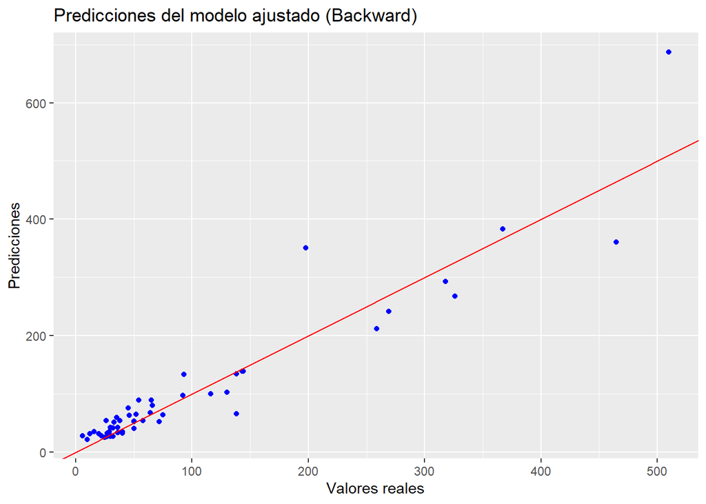

```r
# Crear el gráfico de dispersión
library(ggplot2)
# Unir datos prueba con la predicciones
datos.train.pred <- cbind(datos.test, predicciones)

backward.plot <- ggplot(datos.train.pred, aes(x = datos.test$perf, y = predicciones)) +
  geom_point(color = "blue") +
  geom_abline(color = "red") +
  xlab("Valores reales") +
  ylab("Predicciones") +
  ggtitle("Predicciones del modelo ajustado (Backward)")


backward.plot
```

## Regresión ridge

```r
# Ajustar el modelo de regresión ridge usando el conjunto de entrenamiento
library(glmnet)
X.entrenamiento <- as.matrix(datos.train[, -1])
y.entrenamiento <- datos.train$perf
modelo.ridge <- cv.glmnet(X.entrenamiento, y.entrenamiento, alpha=0,type.measure ="mse",
standardize=T)

# Evaluar el modelo usando el conjunto de prueba
X.prueba <- as.matrix(datos.test[, -1])
y.prueba <- datos.test$perf
predicciones.ridge <- predict(modelo.ridge, newx=X.prueba)
R2.ridge <- cor(predicciones.ridge, y.prueba)^2
ECM.ridge <- mean((y.prueba - predicciones.ridge)^2)

# Imprimir resultados
cat("R2:", R2.ridge, "ECM:", ECM.ridge)
```

```
## R2: 0.9701968 ECM: 452.1491
```

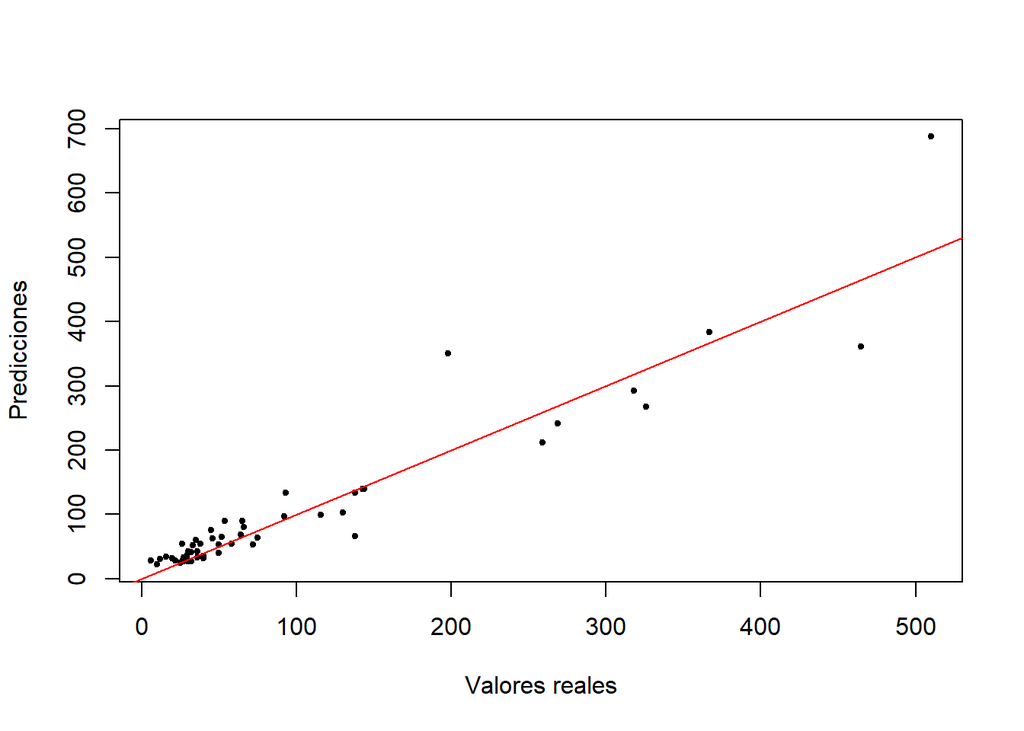

```r
# Graficar las predicciones del modelo en comparación con los valores reales
ridge.plot <- plot(y.prueba, predicciones, pch=20, cex=0.8, xlab="Valores reales", ylab="Predicciones")
abline(0, 1, col="red")
```

El resultado de este código muestra una gráfica de dispersión con los puntos representando los valores reales y las predicciones del modelo. Los puntos deben estar cerca de la línea de identidad (roja), lo que indica que el modelo está haciendo buenas predicciones.

El parámetro lambda es un factor de regularización que se utiliza para reducir el sobreajuste en el modelo.

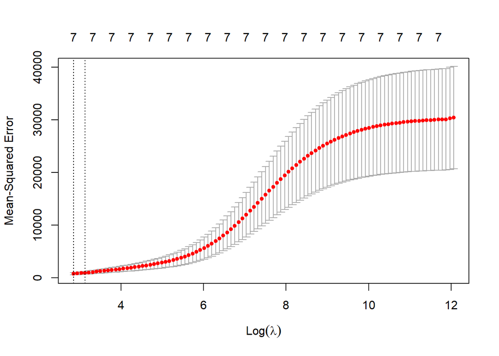

```r
modelo.lambda<-cv.glmnet(x=X.entrenamiento,y=y.entrenamiento,alpha=0,
                         type.measure=c("mse"),
                         standarize=T)
plot(modelo.lambda)
```

```r
mejor.lambda<-modelo.lambda$lambda.min
mejor.lambda
```

```
## [1] 17.31875
```

El log de del mejor lambda es igual a $log(mejor.lambda)=2.851789$.

Los coeficientes del modelo ridge son los coeficientes de la regresión ridge ajustada a los datos. El hecho de que un coeficiente sea mayor o menor no necesariamente indica que la variable correspondiente es la “mejor” del modelo.

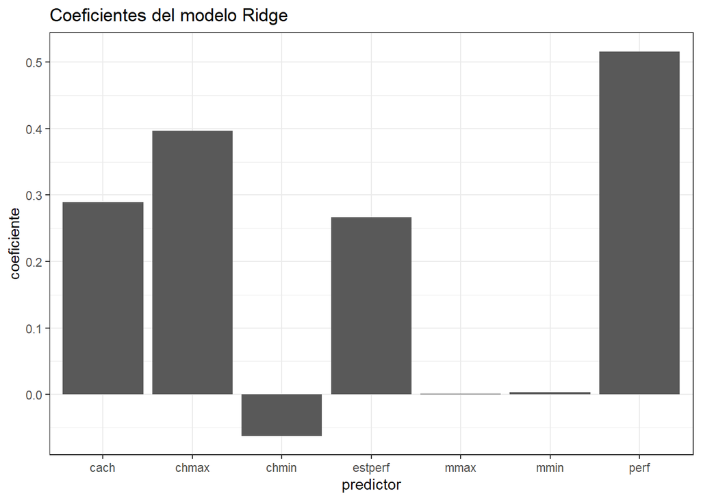

```r
modelo.ridge.mlam <- glmnet(x=X.entrenamiento,y=y.entrenamiento,alpha=0,
                     lambda=mejor.lambda)
library(dplyr)
df_coeficientes<-coef(modelo.ridge.mlam) %>% as.matrix() %>% as_tibble(rownames="predictor") %>% rename(coeficiente=s0)
  #%>% une las funciones

library(ggplot2)
df_coeficientes %>% filter(predictor!="(Intercept)") %>% ggplot(aes(x=predictor,y=coeficiente)) + geom_col() +
  labs(title="Coeficientes del modelo Ridge") + theme_bw()
```

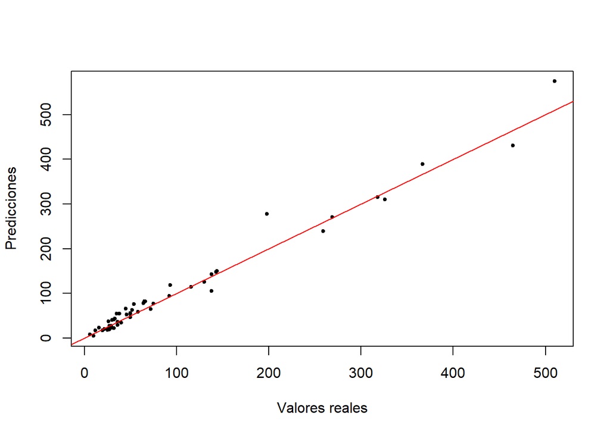

```r
predicciones.lam <- predict(modelo.ridge.mlam, newx=X.prueba)
modelo.lambda.plot <- plot(y.prueba, predicciones.lam, pch=20, cex=0.8, xlab="Valores reales", ylab="Predicciones")
abline(0, 1, col="red")
```

```r
R2.ridge.lam <- cor(predicciones.lam, y.prueba)^2
ECM.ridge.test.lam <- mean((y.prueba - predicciones.ridge)^2)
predicciones.ridge.entrenamiento <- predict(modelo.ridge.mlam, newx=X.entrenamiento)
ECM.ridge.train.lam <- mean((y.entrenamiento - predicciones.ridge.entrenamiento)^2)

# Imprimir resultados
cat("R2:", R2.ridge.lam, "ECM:", ECM.ridge.test.lam)
```

```
## R2: 0.9769694 ECM: 452.1491
```

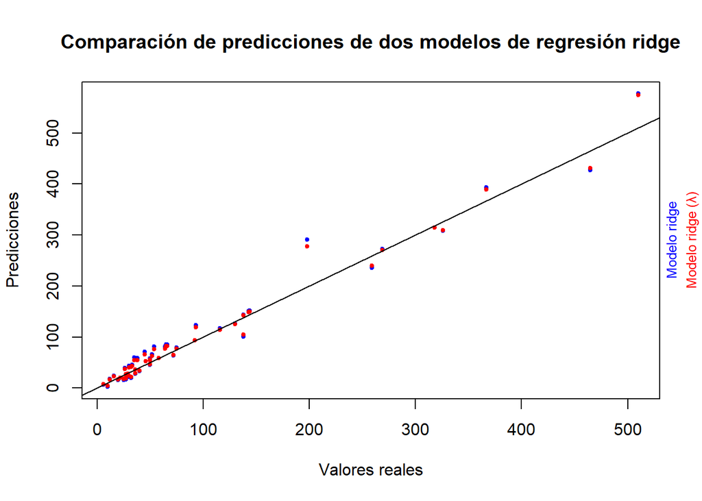

```r
plot(y.prueba, predicciones.ridge, pch=20, cex=0.8, xlab="Valores reales", ylab="Predicciones", col="blue")
points(y.prueba, predicciones.lam, pch=20, cex=0.8, col="red")
title(main="Comparación de predicciones de dos modelos de regresión ridge")
mtext("Modelo ridge", side=4, line=0, col="blue", cex=0.8)
mtext("Modelo ridge (λ)", side=4, line=1, col="red", cex=0.8)
abline(0, 1, col="black")
```

Como el Modelo Ridge tiene una calidad del modelo tanto para el mejor lambda cuanto para el normal la diferencia será pequeña en el ajuste de la predicción.

Comparamos con el modelo anterior:

```r
resultados <- c(ECM.backward.train,ECM.ridge.train.lam)
resultados<-rbind(resultados, c(ECM.backward.test,ECM.ridge.test.lam))
colnames(resultados) <- c("Backward","Ridge")
rownames(resultados) <- c("Entrenamiento","Validación (test)")
resultados
```

```
##                   Backward    Ridge
## Entrenamiento     1708.368 507.1085
## Validación (test) 1681.323 452.1491
```

Este modelo se comporta mejor que su antecesor *Selección de variables hacia atrás* (*Backward).* Este modelo se comporta mejor en validación. Seguimos con los próximos algoritmos en busca de una mejora al problema.

## Regresion Lasso

```r
library(glmnet)

#Dividimos los datos en conjunto de entrenamiento y de prueba
train_idx <- sample(nrow(datos), round(0.75 * nrow(datos)))
train_data <- datos[train_idx, ]
test_data <- datos[-train_idx, ]

#Buscamos la mejor lambda por el metodo de validacion cruzada
x <- as.matrix(train_data[, -1])
y <- train_data$perf
cvfit <- cv.glmnet(x, y, alpha = 1)

#Aplicamos el valor de lambda (minima)
lambda_optima <- cvfit$lambda.min
modelo_lasso <- glmnet(x, y, alpha = 1, lambda = lambda_optima)

#Calculamos el Error Cuadratico Medio MSE  que sera lo que nos hemos confundido a la hora de predecir la variable perf con estos valores
x_test <- as.matrix(test_data[, -1])
y_test <- test_data$perf
y_pred <- predict(modelo_lasso, newx = x_test)
y_pred_train <- predict(modelo_lasso, newx = x)
ECM.lasso.train <- mean((y - y_pred_train)^2)
ECM.lasso.test <- mean((y_test - y_pred)^2)
R2.lasso <- 1 - (ECM.lasso.test / var(y_test)) * ((nrow(x_test) - 1) / (nrow(x_test) - ncol(x_test) - 1))

# Imprimir resultado
cat("ECM:", ECM.lasso.test, "R2:", R2.lasso)
```

```
## ECM: 9.666963 R2: 0.9989571
```

Ahora calculamos el ECM para este modelo:

```r
resultados <- c(ECM.backward.train,ECM.ridge.train.lam,ECM.lasso.train)
resultados<-rbind(resultados, c(ECM.backward.test,ECM.ridge.test.lam,ECM.lasso.test))
colnames(resultados) <- c("Backward","Ridge","Lasso")
rownames(resultados) <- c("Entrenamiento","Validación (test)")
resultados
```

```
##                   Backward    Ridge     Lasso
## Entrenamiento     1708.368 507.1085 25.977087
## Validación (test) 1681.323 452.1491  9.666963
```

Existe una redución significativa en comparación con los otros modelos, hay una mejora considerable en la validación. Este modelo es el mejor para predicir el rendimiento (*perf*).

## Regresion KNN

```r
# Dividir los datos en conjuntos de entrenamiento y prueba
datos.train <- datos[id.train, ]
datos.test <- datos[-id.train, ]

# Cargar el paquete "class"
library(class)

# Definir el número de vecinos
k <- 3
#Con k=3 vecinos da la precision mas alta de los valores posibles

# Aplicar el algoritmo K-NN para clasificación
predicciones <- knn(datos.train[, 1:4], datos.test[, 1:4], datos.train[, k], k)
predicciones.train <- knn(datos.train[, 1:4], datos.train[, 1:4], datos.train[, k], k)

ECM.knn.test <- mean((as.numeric(predicciones) - datos.test[, 5])^2)
ECM.knn.train <- sqrt(mean((datos.train[, 5] - as.numeric(predicciones.train))^2))

# Calcular la precisión del modelo
precision <- mean(predicciones == datos.test[, k]); R2.knn <- precision
cat("La precisión del modelo es:", precision)
```

```
## La precisión del modelo es: 0.9245283
```

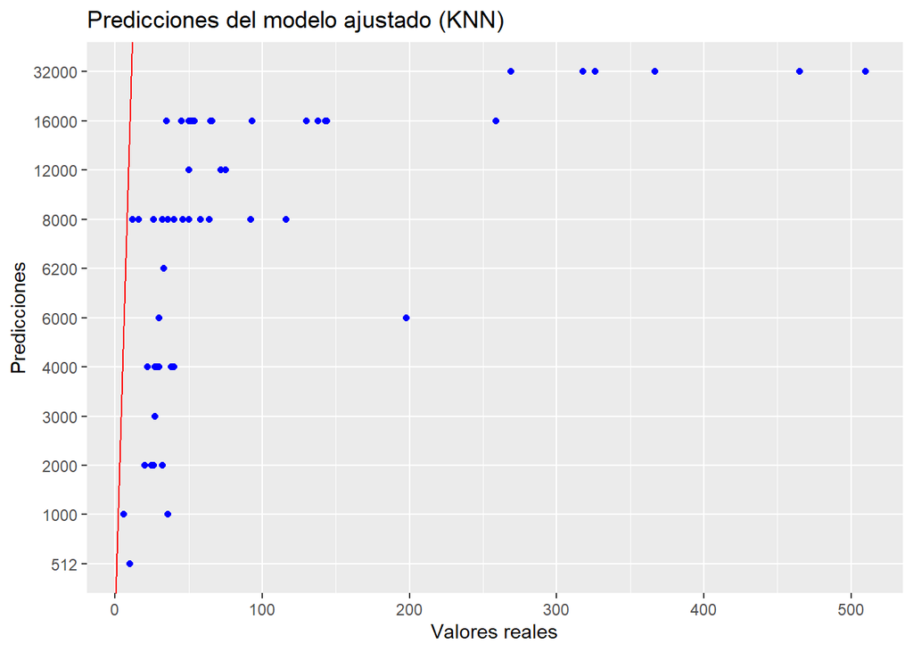

```r
# Crear el gráfico de dispersión
library(ggplot2)
# Unir datos prueba con la predicciones
datos.train.pred <- cbind(datos.test, predicciones)

backward.plot <- ggplot(datos.train.pred, aes(x = datos.test$perf, y = predicciones)) +
  geom_point(color = "blue") +
  geom_abline(color = "red") +
  xlab("Valores reales") +
  ylab("Predicciones") +
  ggtitle("Predicciones del modelo ajustado (KNN)")


backward.plot
```

Con el ECM de este modelo volvemos a comparar el valor ECM del conjunto de entranamiento y de prueba:

```r
resultados <- c(ECM.backward.train,ECM.ridge.train.lam,ECM.lasso.train,ECM.knn.train)
resultados<-rbind(resultados, c(ECM.backward.test,ECM.ridge.test.lam,ECM.lasso.test,ECM.knn.test))
colnames(resultados) <- c("Backward","Ridge","Lasso","KNN")
rownames(resultados) <- c("Entrenamiento","Validación (test)")
resultados
```

```
##                   Backward    Ridge     Lasso       KNN
## Entrenamiento     1708.368 507.1085 25.977087  9.922133
## Validación (test) 1681.323 452.1491  9.666963 90.622642
```

Este modelo no es capaz de predicir bien el predicir el rendimiento (*perf*). Así que, el mejor modelo para esta predicción es el Lasso.